# Regression-Based Classification

Applied Machine Learning in Economics

# 1 Preliminaries

We are going to cover how to implement a linear probability model, binomial logistic regression, multinomial logistic regression, and marginal effects of these models.

Let’s load in some packages!

```r
library(tidyverse) # woo!
library(margins)   # margins()
library(nnet)      # multinom

# Let's use read.csv for some diversity
ahs = read.csv('C:/Users/johnj/Documents/Data/Applied ML ECON490/Lecture Data/lecture data discrete.csv') %>%
  as_tibble
```

The `margins` package helps us with finding the marginal effect of a function. We are also using `nnet` which has a useful multinomial logistic regression. However, this is not the package we are going to be using for our neural network module. `nnet` is quite limited in its scope.

# 2 LPM vs Logistic Inference

As I mentioned in the recorded portion of the lecture, LPM and logistic regression produce *nearly* identical marginal effects.

## 2.1 LPM Marginal Effects

Let’s start off with a simple example.

```r
lfit = lm(renter ~ baths, ahs)
summary(lfit)
```

```
##
## Call:
## lm(formula = renter ~ baths, data = ahs)
##
## Residuals:
##     Min      1Q  Median      3Q     Max
## -0.9655 -0.3162 -0.1539  0.3591  1.3331
##
## Coefficients:
##              Estimate Std. Error t value Pr(>|t|)
## (Intercept)  0.965544   0.008712   110.8   <2e-16 ***
## baths       -0.324671   0.004484   -72.4   <2e-16 ***
## ---
## Signif. codes:  0 '***' 0.001 '**' 0.01 '*' 0.05 '.' 0.1 ' ' 1
##
## Residual standard error: 0.4204 on 15483 degrees of freedom
## Multiple R-squared:  0.2529, Adjusted R-squared:  0.2529
## F-statistic:  5242 on 1 and 15483 DF,  p-value: < 2.2e-16
```

This output shows us that increasing the number of baths by 1 is associated with an decrease of 0.32pp in the probability that the unit is rented.

## 2.2 Logistic Marginal Effects

to run a logistic regression, we need to use a generalized linear model `glm`. We are dealing with an indicator response variable, which means we need the binomial distribution.

```r
gfit = glm(renter ~ baths, ahs, family = 'binomial')
summary(gfit)
```

```
##
## Call:
## glm(formula = renter ~ baths, family = "binomial", data = ahs)
##
## Deviance Residuals:
##     Min       1Q   Median       3Q      Max
## -2.3654  -0.7407  -0.4750   0.8648   3.1772
##
## Coefficients:
##             Estimate Std. Error z value Pr(>|z|)
## (Intercept)  2.73467    0.05577   49.03   <2e-16 ***
## baths       -1.94387    0.03423  -56.79   <2e-16 ***
## ---
## Signif. codes:  0 '***' 0.001 '**' 0.01 '*' 0.05 '.' 0.1 ' ' 1
##
## (Dispersion parameter for binomial family taken to be 1)
##
##     Null deviance: 20627  on 15484  degrees of freedom
## Residual deviance: 15916  on 15483  degrees of freedom
## AIC: 15920
##
## Number of Fisher Scoring iterations: 5
```

Now hold your horses, Julian! I thought you said the marginal effects were very similar!

And to that I would say, they are! We are currently looking at the output for the log-odds ratio. Remember:
$$log \left( \frac{p(x)}{1-p(x)} \right) = \beta_0 + \beta_1 baths$$
We need to use our marginal effects formula!
$$\frac{\partial p(X)}{\partial \beta_1} = \frac{e^{\beta_0 + x \beta_1}}{(1+e^{\beta_0 + x \beta_1})^2} \beta_1$$

To calculate the marginal effects, we are going to use the two different techniques:

1. Average of the covariates
2. Average of predicted values

### 2.2.1 Marginal Effects - Covariate Averages

First, let’s grab the coefficients and then output the marginal effect.

```r
beta = coef(gfit)
xbar = mean(ahs$baths)

exp(beta[1] + beta[2]*xbar)/(  (1 + exp(beta[1] + beta[2]*xbar))^2  )*beta[2]
```

```
## (Intercept)
##   -0.424094
```

I’d say that is a bit closer to the LPM’s estimate.

### 2.2.2 Marginal Effects - Predicted Value Averages

Recall that we can alternatively use
$$\frac{1}{n}\sum_{i=1}^n \frac{e^{\hat{y_i}}}{(1+e^\hat{y_i})^2} \hat{\beta}_1$$
for the marginal effects.

```r
yhat = predict(gfit, ahs)

mean(  exp(yhat)/ (1+exp(yhat))^2*coef(gfit)[-1] )
```

```
## [1] -0.33304
```

```r
# QUESTION:
#      What does the [-1] do?
#      Why do we do it?
```

That looks a lot closer to the LPM output! This is the all (that I know of) statistical packages calculate the marginal effects.

```r
margins(gfit)
```

```
## Average marginal effects
```

```
## glm(formula = renter ~ baths, family = "binomial", data = ahs)
```

```
##   baths
##  -0.333
```

See? We just explored what is going on under the hood in the function `margins()`!

**A word of caution:** I played around with the `margins()` function on larger data sets, and it takes a *long* while to produce the output. I highly recommend typing out the equation manually to save yourself from staring at the red stop sign at the top right of the console for hours (well, probably several seconds to a few minutes). I have no idea why `margins()` is so inefficient.

### 2.2.3 A More Elaborate Model

Let’s move on to a more interesting model.

#### 2.2.3.1 A Better Sample-Splitting Technique

```r
set.seed(490)
train = ahs %>% sample_frac(0.75)
test  = anti_join(ahs, train, by = 'id')
```

I am showing you multiple ways to perform sample-splitting to make the point that there is not a unique solution to coding. I deliberately started with the more fundamental level to show you what is going on within each of these functions. I hope this demystifies some of the black box. `sample_frac()` is my preferred method of sample-splitting.

Back to the more elaborate model.

```r
bfit = glm(renter ~ log(cost)*hoa + npeople + log(hinc) + beds*baths  + lotsize + yos + condo + garage +
            bld + crime + hinf + houtf, train, family = "binomial")
summary(bfit)
```

```
##
## Call:
## glm(formula = renter ~ log(cost) * hoa + npeople + log(hinc) +
##     beds * baths + lotsize + yos + condo + garage + bld + crime +
##     hinf + houtf, family = "binomial", data = train)
##
## Deviance Residuals:
##     Min       1Q   Median       3Q      Max
## -3.1741  -0.4752  -0.2378   0.2917   3.2880
##
## Coefficients:
##                     Estimate Std. Error z value Pr(>|z|)
## (Intercept)        1.7671554  0.6055531   2.918  0.00352 **
## log(cost)          0.6012373  0.0514786  11.679  < 2e-16 ***
## hoaTRUE           -2.8304237  0.6738854  -4.200 2.67e-05 ***
## npeople            0.3678390  0.0474797   7.747 9.39e-15 ***
## log(hinc)         -0.2006294  0.0311381  -6.443 1.17e-10 ***
## beds              -1.0325496  0.0877127 -11.772  < 2e-16 ***
## baths             -1.2969559  0.1446702  -8.965  < 2e-16 ***
## lotsize           -0.1271287  0.0290006  -4.384 1.17e-05 ***
## yos               -0.0928022  0.0128261  -7.235 4.64e-13 ***
## condoTRUE         -1.6296139  0.1113050 -14.641  < 2e-16 ***
## garageTRUE        -0.5733523  0.0696814  -8.228  < 2e-16 ***
## bldApt >= 10       0.1662101  0.1130498   1.470  0.14150
## bldAttached SFH   -1.5526237  0.1222047 -12.705  < 2e-16 ***
## bldDetached SFH   -3.3886660  0.1174369 -28.855  < 2e-16 ***
## bldMobile Home    -3.5331587  0.2195538 -16.092  < 2e-16 ***
## crime              0.0037908  0.0005555   6.824 8.85e-12 ***
## hinf               0.7856501  0.0603959  13.008  < 2e-16 ***
## houtf             -0.4365829  0.0580404  -7.522 5.39e-14 ***
## log(cost):hoaTRUE  0.2084932  0.0933759   2.233  0.02556 *
## beds:baths         0.2550057  0.0445540   5.724 1.04e-08 ***
## ---
## Signif. codes:  0 '***' 0.001 '**' 0.01 '*' 0.05 '.' 0.1 ' ' 1
##
## (Dispersion parameter for binomial family taken to be 1)
##
##     Null deviance: 15473.6  on 11613  degrees of freedom
## Residual deviance:  7177.9  on 11594  degrees of freedom
## AIC: 7217.9
##
## Number of Fisher Scoring iterations: 6
```

Yup! That is a lot more variables!

But guess what? We can still explore *all* the marginal effects of these coefficients in two lines of code!

```r
yhat = predict(bfit, ahs)
mean(exp(yhat)/(1 + exp(yhat))^2) * coef(bfit)[-1]
```

```
##         log(cost)           hoaTRUE           npeople         log(hinc)
##      0.0556038695     -0.2617643733      0.0340186367     -0.0185546877
##              beds             baths           lotsize               yos
##     -0.0954926631     -0.1199455869     -0.0117571639     -0.0085825723
##         condoTRUE        garageTRUE      bldApt >= 10   bldAttached SFH
##     -0.1507106019     -0.0530249943      0.0153715116     -0.1435903606
##   bldDetached SFH    bldMobile Home             crime              hinf
##     -0.3133919549     -0.3267549825      0.0003505802      0.0726588084
##             houtf log(cost):hoaTRUE        beds:baths
##     -0.0403762362      0.0192819504      0.0235835365
```

## 2.3 Model Performance

Let’s take a look at how well this model does at predicting renter status. First, we will grab the predicted probabilities using a threshold of $\psi = 0.5$.

```r
psi = 0.5
phat = ifelse(predict(bfit, test, type = 'response') >= psi,
              TRUE,
              FALSE)
summary(phat)
```

```
##    Mode   FALSE    TRUE
## logical    2531    1340
```

```r
table(test$renter)
```

```
##
## FALSE  TRUE
##  2387  1484
```

Just looking at the raw counts of renters and predicted renters, we seem to be heading in the right direction! However, we could have a complete mismatch between which are predicted to be renters and those that truly are renters. This leads us to exploring the error rate:
$$\text{error rate} = \frac{1}{n} \sum_{i=1}^n \text{I}\{y_i \neq \hat{y}_i\}$$
Or in code:

```r
1/dim(test)[1] * sum(phat != test$renter)
```

```
## [1] 0.1203823
```

As far as error rates go, I’d say this one is decent.

But you need to remember that this error rate is a function of the threshold that we chose. We can actually sweep across the different thresholds to determine which is best.

```r
psi.grid = tibble(psi = seq(0.05, 0.95, by = 0.05), error_rate = 0)

for(a in 1:dim(psi.grid)[1]){
  phat = ifelse(predict(bfit, test, type = 'response') >= psi.grid$psi[a],
                TRUE,
                FALSE)
  psi.grid[a,2] = 1/dim(test)[1]* sum(phat != test$renter)
}
psi.grid
```

```
## # A tibble: 19 x 2
##      psi error_rate
##    <dbl>      <dbl>
##  1  0.05      0.419
##  2  0.1       0.282
##  3  0.15      0.214
##  4  0.2       0.181
##  5  0.25      0.162
##  6  0.3       0.148
##  7  0.35      0.132
##  8  0.4       0.126
##  9  0.45      0.122
## 10  0.5       0.120
## 11  0.55      0.120
## 12  0.6       0.118
## 13  0.65      0.119
## 14  0.7       0.121
## 15  0.75      0.125
## 16  0.8       0.133
## 17  0.85      0.142
## 18  0.9       0.162
## 19  0.95      0.227
```

Well, that is annoying to look at.

Remember the thing about humans being visual creatures, so if you can plot then you should? Well, this is one of those cases.

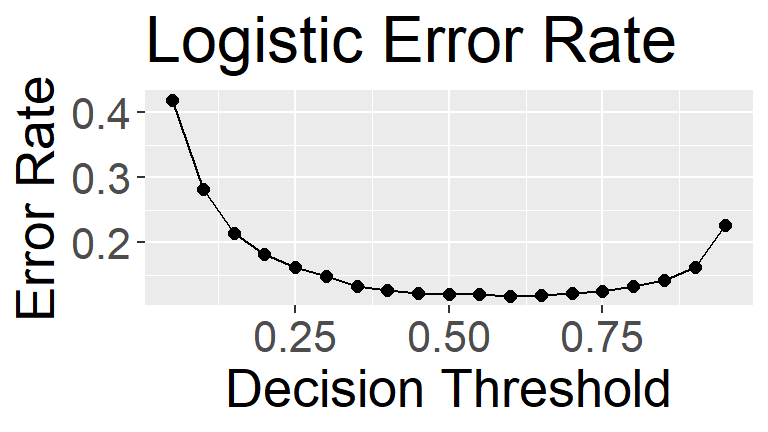

```r
ggplot(psi.grid, aes(x = psi, y = error_rate)) +
  geom_point(size = 2) +
  geom_line() +
  theme(text = element_text(size = 20)) +
  labs(x = 'Decision Threshold', y = 'Error Rate', title = 'Logistic Error Rate')
```

As the figure shows us, choosing a threshold of 0.6 is the best we can do given this training and testing data. We will talk about a better method of selecting a threshold (or *hyperparameter*) in the next module of this class.

# 3 Multinomial Logistic Regression

Recall from the recording that multinomial logistic regression (and binomial) are all relative to a baseline. In multinomial, we are going to end up with $K-1$ different sets of parameters.

$$log \left( \frac{\text{Pr}(G = k|X = x)}{\text{Pr}(G = K|X = x)} \right) = \beta_{0,k} + \beta_{1,k} X$$
Where we could have many $X$ variables.

As a refresher, we calculate the probabilities like so:
$$\text{Pr}(G = k|X = x) = \frac{e^{\beta_{0,k} + \beta_{1,k} x}}{1 + \sum_{l=1}^{K-1} e^{\beta_{0,l} + \beta_{1,l} x}}$$

Now, off to producing the multinomial fit.

```r
mfit = multinom(npeople ~ log(cost)*hoa + log(hinc) + beds*baths  + lotsize + yos + condo + garage +
           bld + crime + hinf + houtf, train)
(smfit = summary(mfit))
```

```
## Call:
## multinom(formula = npeople ~ log(cost) * hoa + log(hinc) + beds *
##     baths + lotsize + yos + condo + garage + bld + crime + hinf +
##     houtf, data = train)
##
## Coefficients:
##   (Intercept)  log(cost)   hoaTRUE log(hinc)      beds     baths     lotsize
## 2   -7.942186 0.07871904 0.7495676 0.5458239 0.7633839 0.7082825  0.05925922
## 3  -14.194549 0.21318108 1.3074274 0.8042401 1.7505701 1.1154559 -0.04087948
##            yos  condoTRUE garageTRUE bldApt >= 10 bldAttached SFH
## 2  0.053032359 -0.3181399 -0.1605783  -0.03334199      -0.1187012
## 3 -0.001569162 -0.5222305 -0.4792183  -0.47108241      -0.5688430
##   bldDetached SFH bldMobile Home         crime       hinf       houtf
## 2       0.1636064      0.2377605 -0.0012324310 0.15929414 -0.20420445
## 3      -0.4548092     -0.4596846 -0.0002679701 0.01312578 -0.09384274
##   log(cost):hoaTRUE beds:baths
## 2        -0.1049790 -0.1958849
## 3        -0.2050311 -0.3587334
##
## Std. Errors:
##   (Intercept)  log(cost)     hoaTRUE  log(hinc)       beds     baths    lotsize
## 2  0.01236175 0.03439400 0.008074631 0.02502765 0.06171735 0.1021204 0.01925900
## 3  0.01466199 0.04727104 0.008337868 0.03583338 0.08673765 0.1433604 0.02754135
##           yos  condoTRUE garageTRUE bldApt >= 10 bldAttached SFH
## 2 0.009506225 0.08451348 0.05704095   0.07792783      0.09885028
## 3 0.012955815 0.12941305 0.07830072   0.12398023      0.13541250
##   bldDetached SFH bldMobile Home        crime       hinf      houtf
## 2      0.08993106      0.1716130 0.0002974998 0.04124202 0.03811180
## 3      0.12210558      0.2520109 0.0004112511 0.05624943 0.05202656
##   log(cost):hoaTRUE beds:baths
## 2       0.008990254 0.02949396
## 3       0.011133891 0.03871053
##
## Residual Deviance: 20350.36
## AIC: 20426.36
```

Since we have $K=3$ groups, we have 2 sets of coefficients for the regression. But, we don’t have the p-values! I live for the p-values!!!!

From the recording, you should remember that we are imposing a distributional form on these estimates, which means we are going to be using a Z-test, not a t-test. Here $Z = \frac{\hat{\beta} - \beta_0}{se(\hat{\beta})}$, where $\beta_0 = 0$. The associate p-values are given by $p = (1 - \Phi(Z))*2$, where $\Phi(\cdot)$ is the standard normal distribution. We are multiplying by two because we want to use a two-sided test.

```r
smfit$z = smfit$coefficients/smfit$standard.errors

smfit$p = (1 - pnorm(abs(smfit$z)))*2
smfit$p
```

```
##   (Intercept)    log(cost) hoaTRUE log(hinc) beds        baths     lotsize
## 2           0 2.209428e-02       0         0    0 4.040546e-12 0.002091214
## 3           0 6.490077e-06       0         0    0 7.105427e-15 0.137730727
##            yos    condoTRUE   garageTRUE bldApt >= 10 bldAttached SFH
## 2 2.423254e-08 0.0001669706 4.875594e-03 0.6687549881    2.298219e-01
## 3 9.035988e-01 0.0000545146 9.344163e-10 0.0001448963    2.659546e-05
##   bldDetached SFH bldMobile Home        crime        hinf        houtf
## 2    0.0688744833     0.16591627 3.433479e-05 0.000112268 8.413056e-08
## 3    0.0001955316     0.06814202 5.146611e-01 0.815490009 7.127102e-02
##   log(cost):hoaTRUE   beds:baths
## 2                 0 3.104494e-11
## 3                 0 0.000000e+00
```

Looks like we have some super significant coefficients and some that are not at all.

## 3.1 Inference

It is time for the messiest interpretation of the semester. Let’s give interpreting the coefficient on attached single family homes on three+ person occupied units a whirl.

*“A single family home unit decreases the log odds ratio of three+ person units to one person units by 0.57 relative to the baseline unit of apartments with fewer than 10 units.”*

$$Gross.$$

## 3.2 Marginal Effects

We can perform the same exact steps to calculate the marginal effect of each of these coefficients. This will produce a matrix, because we have a matrix of coefficients.

```r
yhat = predict(mfit, test, type = 'probs') # type = c('class', 'probs')

mean(exp(yhat)/((1+exp(yhat))^2))*coef(mfit)
```

```
##   (Intercept)  log(cost)   hoaTRUE log(hinc)      beds     baths      lotsize
## 2   -1.911696 0.01894779 0.1804220 0.1313806 0.1837476 0.1704847  0.014263783
## 3   -3.416649 0.05131300 0.3146997 0.1935818 0.4213648 0.2684919 -0.009839752
##             yos   condoTRUE  garageTRUE bldApt >= 10 bldAttached SFH
## 2  0.0127649676 -0.07657674 -0.03865143 -0.008025468     -0.02857155
## 3 -0.0003776997 -0.12570166 -0.11534855 -0.113390236     -0.13692136
##   bldDetached SFH bldMobile Home         crime        hinf       houtf
## 2       0.0393803      0.0572293 -2.966480e-04 0.038342336 -0.04915231
## 3      -0.1094732     -0.1106468 -6.450079e-05 0.003159394 -0.02258809
##   log(cost):hoaTRUE  beds:baths
## 2       -0.02526861 -0.04714980
## 3       -0.04935130 -0.08634766
```

**Note:** the prediction type for a `multinom` object is different than a `glm` object.

## 3.3 Model Performance

Time for those same two lines of code.

```r
yhat = predict(mfit, test)

1/length(yhat)* sum(yhat != test$npeople)
```

```
## [1] 0.4241798
```

Ouch… We did not do very well. To put this into perspective, if we assume that we have equal size groups of 1, 2, and 3+ people (which we don’t), randomly guessing (how about the same number) would give us an error rate of 0.66.

```r
table(test$npeople)
```

```
##
##    1    2    3
## 1574 1613  684
```

```r
# The error rate of just guessing 2 occupants every time
1 - 1613/(dim(test)[1])
```

```
## [1] 0.5833118
```

# 4 Saving for Next Time!

We are going to compare the performance of these models with different models next lecture, so we need to save it. We can do so using a `.rda` file. This format allows us to save multiple objects in one file.

```r
# Grabbing the objects we need
fb = bfit$terms
fm = npeople ~ log(cost)*hoa + log(hinc) + beds*baths  + lotsize + yos + condo + garage + bld + crime + hinf + houtf

save(fb, fm, bfit, mfit, file = 'C:/Users/johnj/Documents/Data/Applied ML ECON490/lecture data/logistic fit.rda')
list.files('C:/Users/johnj/Documents/Data/Applied ML ECON490/lecture data')
```

```
##  [1] "county_2010cbsa.csv"         "countyinflow1516.csv"
##  [3] "countyoutflow1617.csv"       "fbiucr.csv"
##  [5] "gapminder_2007.csv"          "gapminder_all.csv"
##  [7] "household.csv"               "lea to county.xlsx"
##  [9] "lecture data continuous.csv" "lecture data discrete.csv"
## [11] "lecture data.zip"            "logistic fit.rda"
## [13] "math proficiency.csv"        "person.csv"
```